# Homework 4

Author

PSTAT 134/234

## Homework 4

**Note: If this is one of your two late homework submissions, please indicate below; also indicate whether it is your first or second late submission.**

__________________________________

This homework assignment has you practice working with some text data, doing some natural language processing. I strongly advise using Lab 7 for assistance.

You also may need to use other functions. I encourage you to make use of our textbook(s) and use the Internet to help you solve these problems. You can also work together with your classmates. If you do work together, you should provide the names of those classmates below.

Names of Collaborators (if any):

### Natural Language Processing

- Review: This column contains the text of user reviews, reflecting their experiences, opinions, and feedback on the Spotify app.
- Sentiment label: This column categorizes each review as either “POSITIVE” or “NEGATIVE” based on its sentiment.

The data comes from this source at Kaggle: https://www.kaggle.com/datasets/alexandrakim2201/spotify-dataset

#### Exercise 1

Read the data into R (or Python, whichever you prefer).

Take a look at the distribution of `label`. Are there relatively even numbers of negative and positive reviews in the data set?

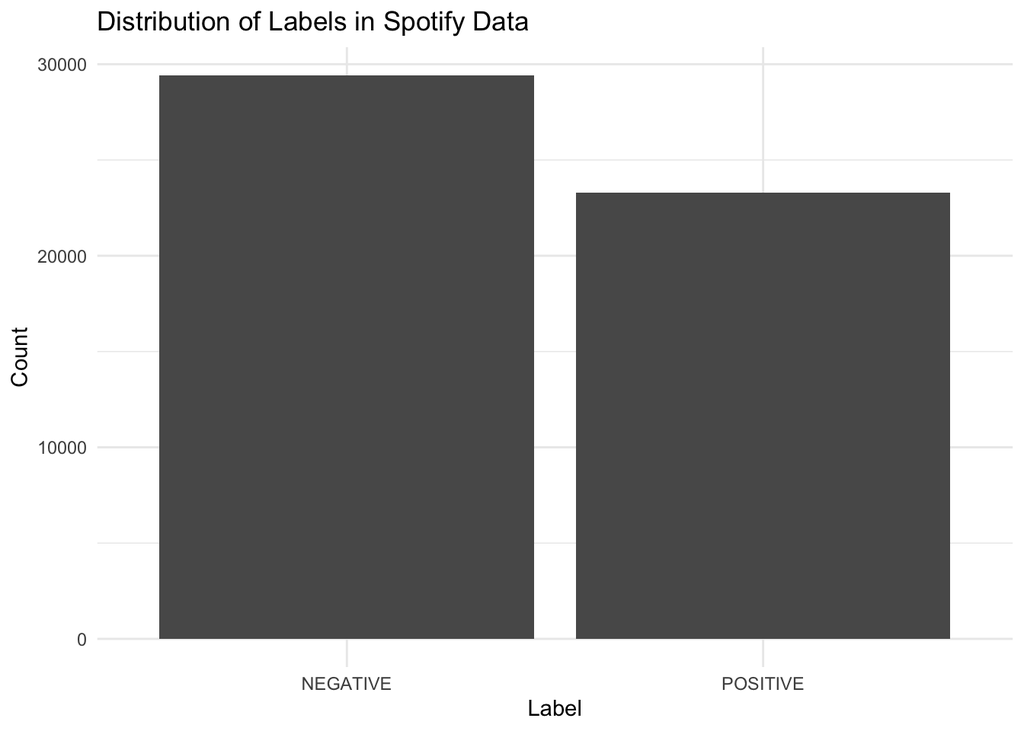

```r
library(tidyverse)
library(tidymodels)
library(reshape2)
library(wordcloud)
library(ggraph)
library(tidytext)
library(httr)
library(igraph)
library(data.table)
library(textdata)
library(ggplot2)
library(ggrepel)
library(plotly)
library(umap)
library(word2vec)
library(tm)
library(kableExtra)
library(LiblineaR)

spotify <- read.csv("data/spotify-review-data.csv")
ggplot(spotify, aes(x = label)) +
  geom_bar() +
  labs(title = "Distribution of Labels in Spotify Data",
       x = "Label",
       y = "Count") +
  theme_minimal()
```

```r
spotify$id <- seq.int(nrow(spotify))
spotify_for_later <- spotify
```

The number of negative reviews and positive reviews is relatively even.

#### Exercise 2

Take a random sample of $10,000$ reviews, stratified by `label`. All further exercises will be working with this smaller sample of reviews.

```r
spotify_sample <- spotify %>%
  group_by(label) %>%
  sample_frac(size = 10000 / nrow(spotify), replace = F) %>%
  ungroup()

# prop.table(table(spotify_sample$label))
```

#### Exercise 3

Tokenize the reviews into words.

Remove stop words. (You can use any pre-made list of stop words of your choice.)

Clean the reviews. Remove punctuation and convert the letters to lowercase.

Verify that this process worked correctly.

```r
spotify_sample %>%
  unnest_tokens(word, Review) %>%
  head(10)
```

```
# A tibble: 10 × 3
   label       id word
   <chr>    <int> <chr>
 1 NEGATIVE 46325 your
 2 NEGATIVE 46325 new
 3 NEGATIVE 46325 updates
 4 NEGATIVE 46325 are
 5 NEGATIVE 46325 terrible
 6 NEGATIVE 46325 i
 7 NEGATIVE 46325 cannot
 8 NEGATIVE 46325 do
 9 NEGATIVE 46325 this
10 NEGATIVE 46325 garbage
```

```r
stop_words %>%
  head(n = 10)
```

```
# A tibble: 10 × 2
   word        lexicon
   <chr>       <chr>
 1 a           SMART
 2 a's         SMART
 3 able        SMART
 4 about       SMART
 5 above       SMART
 6 according   SMART
 7 accordingly SMART
 8 across      SMART
 9 actually    SMART
10 after       SMART
```

```r
# token and no stop words
spotify_sample %>%
  filter(!is.na(Review)) %>%
  unnest_tokens(word, Review) %>%
  anti_join(stop_words) %>%
  count(word, sort = T)
```

```
# A tibble: 8,970 × 2
   word        n
   <chr>   <int>
 1 app      5463
 2 music    3983
 3 spotify  2840
 4 songs    2807
 5 song     2265
 6 play     1825
 7 love     1543
 8 listen   1359
 9 premium  1328
10 ads      1263
# ℹ 8,960 more rows
```

```r
head(spotify_sample, 10)
```

```
# A tibble: 10 × 3
   Review                                                            label    id
   <chr>                                                             <chr> <int>
 1 Your new updates are terrible I cannot do this garbage if it doe… NEGA… 46325
 2 Podcasts sorted alphabetically are not actually alphabetical.     NEGA… 16900
 3 Long, long, long time customer on many different platforms over … NEGA… 38280
 4 plays ads on podcasts even though I have premium, what's worse i… NEGA… 19617
 5 2/5 - currently using Spotify premium but it doesn't work when i… NEGA… 43565
 6 Stop running gay pride ads in my Christian conservative podcasts… NEGA…  9480
 7 App on Android has been terribly buggy for about a year (April 2… NEGA… 27841
 8 Player is disappearing randomly so you cannot pause or move to n… NEGA… 34106
 9 Stopped downloading playlists for offline despite saying downloa… NEGA… 48458
10 As soon as I bought the premium the app started crashing after e… NEGA… 36732
```

```r
# removing HTML tags, replacing with a space
spotify_sample$Review <- str_replace_all(spotify_sample$Review, pattern = "<.*?>", " ")
# removing "\n", replacing with a space
spotify_sample$Review <- str_replace_all(spotify_sample$Review, pattern = "\n", " ")
# removing "&amp;" and "&gt;"
spotify_sample$Review <- str_replace_all(spotify_sample$Review, pattern = "&amp;", " ")
spotify_sample$Review <- str_replace_all(spotify_sample$Review , pattern = "&gt;", " ")

remove <- c('\n',
            '[[:punct:]]',
            'nbsp',
            '[[:digit:]]',
            '[[:symbol:]]',
            '^br$',
            'href',
            'ilink') %>%
  paste(collapse = '|')
# removing any other weird characters,
# any backslashes, adding space before capital
# letters and removing extra whitespace,
# replacing capital letters with lowercase letters
spotify_sample$Review <- spotify_sample$Review %>%
  str_remove_all('\'') %>%
  str_replace_all(remove, ' ') %>%
  str_replace_all("([a-z])([A-Z])", "\\1 \\2") %>%
  tolower() %>%
  str_replace_all("â|ï|ð|ÿ|œ|ž|š|^", " ") %>%
  str_replace_all("\\s+", " ") %>%
  str_trim()

# take a look at random row
spotify_sample$Review[66:69]
```

```
[1] "a pretty buggy application i am regretting buying spotify premium often when i switch songs the music changes but the name art etc of the song doesnt change and the application hangs sometimes when i play a song it isnt visible in the swipe down menu so im unable to pause it or change it ive tr…
[2] "since the new update my touch screen in my truck doesnt recognize spotify that was percent of my use for it i dont think i need to keep the premium subscription anymore"
[3] "i have no issues regarding the quality the problem is that it signes me off even i dont click sign out and whenever i try to log in back it says invalid password even when i try to use to link before hrs it says invalid and i am not able to log in back rn i dont think it is a glitch it happened…
[4] "since update i can no longer listen to music its this what im paying for what a fricken joke edited still having the same dam problem even when song are downloaded starting to piss my off maybe just have to cancel my subscription now its been years since my review and no fix"
```

#### Exercise 4

Create a bar chart of the most commonly-occurring words (not including stop words).

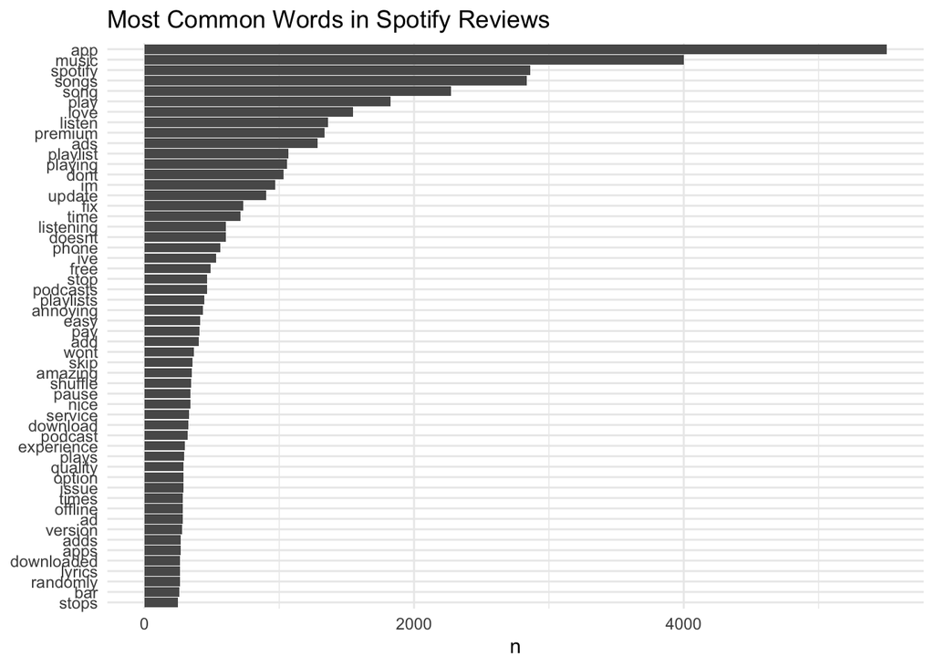

```r
spotify_sample %>%
  unnest_tokens(word, Review) %>%
  anti_join(stop_words) %>%
  count(word, sort = T) %>%
  filter(n > 250) %>%
  mutate(word = reorder(word, n)) %>%
  ggplot(aes(n, word)) +
  geom_col() +
  labs(y = NULL, title = "Most Common Words in Spotify Reviews") +
  theme_minimal()
```

Create bar charts of the most commonly-occurring words, broken down by `label`. What words are more common in positive reviews? What words are more common in negative reviews?

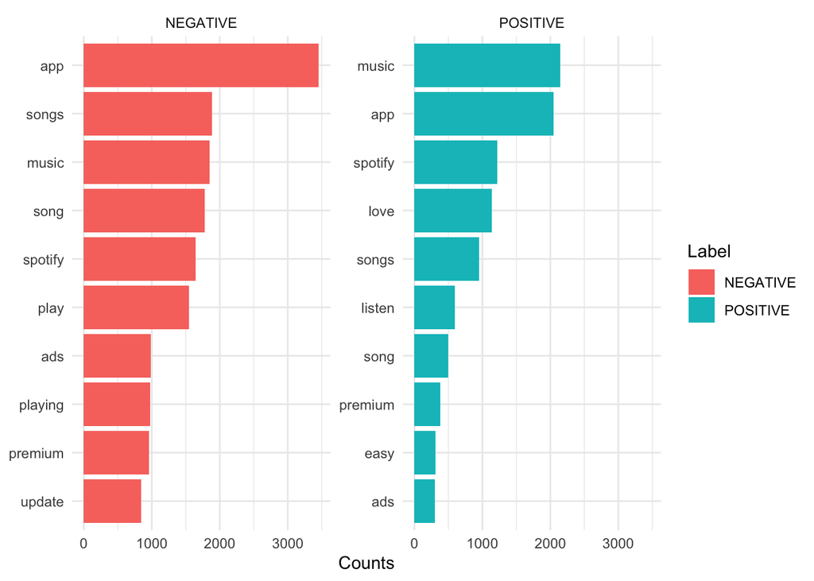

```r
word_counts <- spotify_sample %>%
  unnest_tokens(word, Review) %>%
  anti_join(stop_words) %>%
  count(label, word, sort = T) %>%
  group_by(label) %>%
  slice_max(n, n = 10) %>%
  ungroup()


word_counts %>%
  mutate(word = reorder_within(word, n, label)) %>%
  ggplot(aes(n, word, fill = label)) +
  geom_col() +
  facet_wrap(~label, scales = "free_y") +
  scale_y_reordered() +
  labs(x = "Counts", y = NULL, fill = "Label") +
  theme_minimal()
```

“app” is most common in negative reviews, “music” is the most common words in positive reviews.

#### Exercise 5

Create a word cloud of the most commonly-occurring words overall, broken down by “positive” or “negative” sentiment (using the Bing sentiment lexicon).

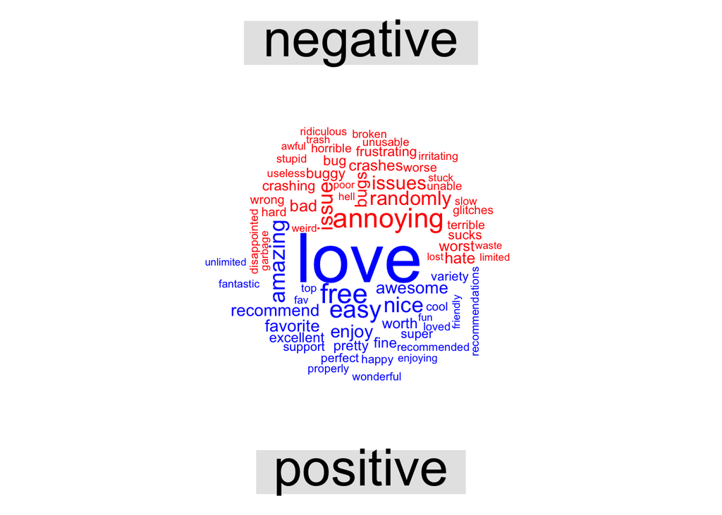

```r
spotify_sample %>%
  unnest_tokens(word, Review) %>%
  anti_join(stop_words) %>%
  ungroup() %>%
  inner_join(get_sentiments("bing")) %>%
  count(word, sentiment, sort = T) %>%
  acast(word ~ sentiment, value.var = "n", fill = 0) %>%
  comparison.cloud(colors = c("red", "blue"), scale = c(4, 0.5), max.words = 70)
```

#### Exercise 6

Calculate the tf-idf values for the words in the dataset.

Find the 30 words with the largest tf-idf values.

Find the 30 words with the smallest tf-idf values.

```r
tf_idf <- spotify_sample %>%
  unnest_tokens(word, Review) %>%
  anti_join(stop_words) %>%
  count(id, label, word) %>%
  bind_tf_idf(term = word,
              document = id,
              n = n)

tf_idf %>%
  arrange(desc(tf_idf)) %>%
  head(n = 30) %>%
  kbl() %>%
  add_header_above(c("Top 30 Words with the Largest TF-IDF Values" = 7)) %>%
  scroll_box(width = "400px", height = "500px")
```

| Top 30 Words with the Largest TF-IDF Values id | Top 30 Words with the Largest TF-IDF Values label | Top 30 Words with the Largest TF-IDF Values word | Top 30 Words with the Largest TF-IDF Values n | Top 30 Words with the Largest TF-IDF Values tf | Top 30 Words with the Largest TF-IDF Values idf | Top 30 Words with the Largest TF-IDF Values tf_idf |
| --- | --- | --- | --- | --- | --- | --- |
| 49305 | POSITIVE | mantul | 1 | 1 | 9.20029 | 9.20029 |
| 49343 | POSITIVE | lisned | 1 | 1 | 9.20029 | 9.20029 |
| 49385 | POSITIVE | gem | 1 | 1 | 9.20029 | 9.20029 |
| 49496 | POSITIVE | bacana | 1 | 1 | 9.20029 | 9.20029 |
| 49744 | POSITIVE | nices | 1 | 1 | 9.20029 | 9.20029 |
| 49860 | POSITIVE | kachra | 1 | 1 | 9.20029 | 9.20029 |
| 49906 | POSITIVE | supersiniz | 1 | 1 | 9.20029 | 9.20029 |
| 50179 | POSITIVE | goooddd | 1 | 1 | 9.20029 | 9.20029 |
| 50191 | POSITIVE | likeee | 1 | 1 | 9.20029 | 9.20029 |
| 50250 | POSITIVE | aaps | 1 | 1 | 9.20029 | 9.20029 |
| 50676 | POSITIVE | superpower | 1 | 1 | 9.20029 | 9.20029 |
| 50730 | POSITIVE | iip | 1 | 1 | 9.20029 | 9.20029 |
| 50736 | POSITIVE | alex | 1 | 1 | 9.20029 | 9.20029 |
| 50792 | POSITIVE | temaa | 1 | 1 | 9.20029 | 9.20029 |
| 50793 | POSITIVE | niceee | 1 | 1 | 9.20029 | 9.20029 |
| 50819 | POSITIVE | loveeees | 1 | 1 | 9.20029 | 9.20029 |
| 51143 | POSITIVE | niec | 1 | 1 | 9.20029 | 9.20029 |
| 51162 | POSITIVE | fjiiok | 1 | 1 | 9.20029 | 9.20029 |
| 51191 | POSITIVE | yayayayyayaayay | 1 | 1 | 9.20029 | 9.20029 |
| 51197 | POSITIVE | goool | 1 | 1 | 9.20029 | 9.20029 |
| 51218 | POSITIVE | yeess | 1 | 1 | 9.20029 | 9.20029 |
| 51392 | POSITIVE | magnetic | 1 | 1 | 9.20029 | 9.20029 |
| 51542 | POSITIVE | ndlovu | 1 | 1 | 9.20029 | 9.20029 |
| 51588 | POSITIVE | chil | 1 | 1 | 9.20029 | 9.20029 |
| 51696 | POSITIVE | wowamazing | 1 | 1 | 9.20029 | 9.20029 |
| 51743 | POSITIVE | bakar | 1 | 1 | 9.20029 | 9.20029 |
| 51770 | POSITIVE | wark | 1 | 1 | 9.20029 | 9.20029 |
| 51932 | POSITIVE | goode | 1 | 1 | 9.20029 | 9.20029 |
| 51986 | POSITIVE | guuude | 1 | 1 | 9.20029 | 9.20029 |
| 52342 | POSITIVE | abhiram | 2 | 1 | 9.20029 | 9.20029 |

```r
tf_idf %>%
  arrange(tf_idf) %>%
  head(n = 30) %>%
  kbl() %>%
  add_header_above(c("Top 30 Words with the Smallest TF-IDF Values" = 7)) %>%
  scroll_box(width = "400px", height = "500px")
```

| Top 30 Words with the Smallest TF-IDF Values id | Top 30 Words with the Smallest TF-IDF Values label | Top 30 Words with the Smallest TF-IDF Values word | Top 30 Words with the Smallest TF-IDF Values n | Top 30 Words with the Smallest TF-IDF Values tf | Top 30 Words with the Smallest TF-IDF Values idf | Top 30 Words with the Smallest TF-IDF Values tf_idf |
| --- | --- | --- | --- | --- | --- | --- |
| 21049 | NEGATIVE | songs | 1 | 0.0081301 | 1.5345366 | 0.0124759 |
| 21049 | NEGATIVE | play | 1 | 0.0081301 | 1.9320670 | 0.0157079 |
| 21049 | NEGATIVE | premium | 1 | 0.0081301 | 2.1536428 | 0.0175093 |
| 21049 | NEGATIVE | listen | 1 | 0.0081301 | 2.1659021 | 0.0176090 |
| 22509 | POSITIVE | app | 1 | 0.0212766 | 0.8636599 | 0.0183757 |
| 21049 | NEGATIVE | ads | 1 | 0.0081301 | 2.3312756 | 0.0189535 |
| 21049 | NEGATIVE | playlist | 1 | 0.0081301 | 2.4538779 | 0.0199502 |
| 39430 | NEGATIVE | app | 1 | 0.0232558 | 0.8636599 | 0.0200851 |
| 4566 | NEGATIVE | app | 1 | 0.0243902 | 0.8636599 | 0.0210649 |
| 21049 | NEGATIVE | app | 3 | 0.0243902 | 0.8636599 | 0.0210649 |
| 39577 | NEGATIVE | app | 1 | 0.0243902 | 0.8636599 | 0.0210649 |
| 10814 | NEGATIVE | app | 1 | 0.0250000 | 0.8636599 | 0.0215915 |
| 19403 | NEGATIVE | app | 1 | 0.0250000 | 0.8636599 | 0.0215915 |
| 37032 | NEGATIVE | app | 1 | 0.0250000 | 0.8636599 | 0.0215915 |
| 40355 | POSITIVE | app | 1 | 0.0250000 | 0.8636599 | 0.0215915 |
| 6329 | NEGATIVE | app | 1 | 0.0256410 | 0.8636599 | 0.0221451 |
| 12099 | NEGATIVE | app | 1 | 0.0256410 | 0.8636599 | 0.0221451 |
| 24689 | NEGATIVE | app | 1 | 0.0256410 | 0.8636599 | 0.0221451 |
| 40486 | POSITIVE | app | 1 | 0.0256410 | 0.8636599 | 0.0221451 |
| 946 | NEGATIVE | app | 1 | 0.0263158 | 0.8636599 | 0.0227279 |
| 4590 | POSITIVE | app | 1 | 0.0263158 | 0.8636599 | 0.0227279 |
| 5294 | POSITIVE | app | 1 | 0.0263158 | 0.8636599 | 0.0227279 |
| 10508 | NEGATIVE | app | 1 | 0.0263158 | 0.8636599 | 0.0227279 |
| 14506 | NEGATIVE | app | 1 | 0.0263158 | 0.8636599 | 0.0227279 |
| 27576 | NEGATIVE | app | 1 | 0.0263158 | 0.8636599 | 0.0227279 |
| 34036 | NEGATIVE | app | 1 | 0.0263158 | 0.8636599 | 0.0227279 |
| 11251 | NEGATIVE | app | 1 | 0.0270270 | 0.8636599 | 0.0233422 |
| 17229 | NEGATIVE | app | 1 | 0.0270270 | 0.8636599 | 0.0233422 |
| 28886 | NEGATIVE | app | 1 | 0.0270270 | 0.8636599 | 0.0233422 |
| 31254 | NEGATIVE | app | 1 | 0.0270270 | 0.8636599 | 0.0233422 |

#### Exercise 7

Find the 30 most commonly occuring bigrams.

```r
nrc_bigrams <- spotify_sample %>%
  unnest_tokens(bigram, Review, token = "ngrams", n = 2) %>%
  separate(bigram, c("word1", "word2"), sep = " ") %>%
  filter(!word1 %in% stop_words$word) %>%
  filter(!word2 %in% stop_words$word) %>%
  filter(!is.na(word1), !is.na(word2)) %>%
  unite(bigram, word1, word2, sep = " ")

nrc_bigrams %>%
  count(bigram, sort = T) %>%
  head(n = 30) %>%
  kbl() %>%
  add_header_above(c("Top 30 Most Common Bigrams" = 2)) %>%
  scroll_box(width = "400px", height = "500px")
```

| Top 30 Most Common Bigrams bigram | Top 30 Most Common Bigrams n |
| --- | --- |
| music app | 394 |
| love spotify | 270 |
| spotify premium | 125 |
| music streaming | 104 |
| internet connection | 98 |
| play music | 95 |
| free version | 89 |
| nice app | 83 |
| play songs | 75 |
| stops playing | 75 |
| random songs | 73 |
| stop playing | 73 |
| amazing app | 71 |
| recent update | 68 |
| joe rogan | 66 |
| wont play | 65 |
| sound quality | 63 |
| streaming app | 61 |
| play button | 59 |
| play pause | 59 |
| buy premium | 58 |
| playing music | 58 |
| favorite songs | 55 |
| play bar | 55 |
| spotify app | 54 |
| im listening | 53 |
| offline mode | 53 |
| ad free | 52 |
| listening music | 52 |
| music apps | 52 |

Create graphs visualizing the networks of bigrams, broken down by `label`. That is, make one graph of the network of bigrams for the positive reviews, and one graph of the network for the negative reviews.

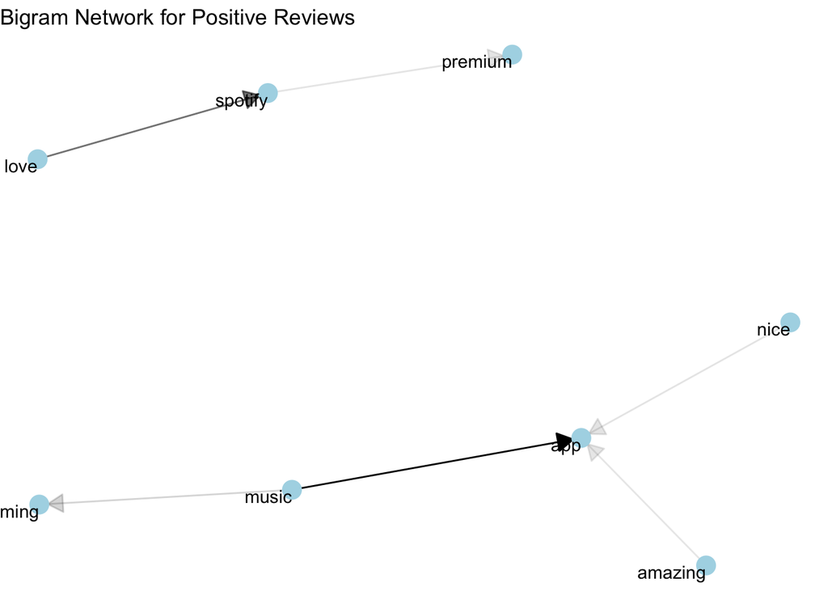

```r
spotify_bigrams_sep <- spotify_sample %>%
  unnest_tokens(bigram, Review, token = "ngrams", n = 2) %>%
  separate(bigram, c("word1", "word2"), sep = " ") %>%
  filter(!word1 %in% stop_words$word) %>%
  filter(!word2 %in% stop_words$word) %>%
  filter(!is.na(word1), !is.na(word2))

a <- grid::arrow(type = "closed", length = unit(.15, "inches"))

# Positive
positive_bigrams <- spotify_bigrams_sep %>%
  filter(label == "POSITIVE") %>%
  count(word1, word2) %>%
  filter(n > 50) %>%
  graph_from_data_frame()

positive_plot <- ggraph(positive_bigrams, layout = "fr") +
  geom_edge_link(aes(edge_alpha = n), show.legend = FALSE,
                 arrow = a, end_cap = circle(.07, 'inches')) +
  geom_node_point(color = "lightblue", size = 5) +
  geom_node_text(aes(label = name), vjust = 1, hjust = 1) +
  ggtitle("Bigram Network for Positive Reviews") +
  theme_void()
positive_plot
```

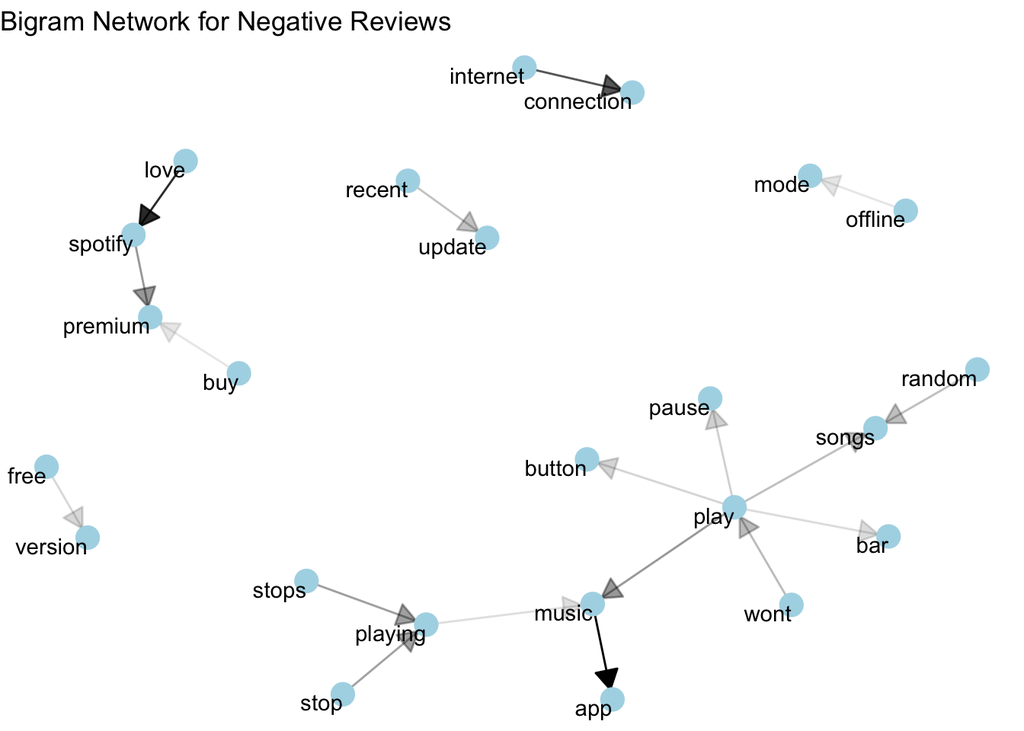

```r
# Negative
negative_bigrams <- spotify_bigrams_sep %>%
  filter(label == "NEGATIVE") %>%
  count(word1, word2) %>%
  filter(n > 50) %>%
  graph_from_data_frame()

negative_plot <- ggraph(negative_bigrams, layout = "fr") +
  geom_edge_link(aes(edge_alpha = n), show.legend = FALSE,
                 arrow = a, end_cap = circle(.07, 'inches')) +
  geom_node_point(color = "lightblue", size = 5) +
  geom_node_text(aes(label = name), vjust = 1, hjust = 1) +
  ggtitle("Bigram Network for Negative Reviews")+
  theme_void()
negative_plot
```

What patterns do you notice?

The arrows really help us interpret the bigram network. We can see phrases like “music app,” “nice app,” and “love spotify” in positive reviews. In negative reviews, people are talking about issues such as “stop playing,” “internet connection,” and “random songs.” The network for negative reviews shows a greater number of connected words compared to positive reviews, suggesting that users discuss a wider range of concerns when expressing dissatisfaction.

#### Exercise 8

Using the tokenized **words** and their corresponding tf-idf scores, fit a **linear support vector machine** to predict whether a given review is positive or negative.

- Split the data using stratified sampling, with 70% training and 30% testing;

```r
set.seed(123)
spotify_df <- tf_idf %>%
  mutate(label = factor(label)) %>%
  select(-word)

data_split <- initial_split(spotify_df, prop = 0.7, strata = label)
train_data <- training(data_split)
test_data <- testing(data_split)
cv_folds <- vfold_cv(train_data, v = 5, strata = label)
```

- Drop any columns with zero variance;

```r
recipe <- recipe(label ~ ., data = train_data) %>%
  step_zv(all_predictors())

prep(recipe) %>% bake(train_data) %>% head()
```

```
# A tibble: 6 × 6
     id     n     tf   idf tf_idf label
  <int> <int>  <dbl> <dbl>  <dbl> <fct>
1    12     1 0.0385  9.20  0.354 NEGATIVE
2    12     1 0.0385  5.23  0.201 NEGATIVE
3    12     1 0.0385  2.89  0.111 NEGATIVE
4    12     2 0.0769  4.88  0.376 NEGATIVE
5    12     2 0.0769  7.12  0.548 NEGATIVE
6    12     1 0.0385  4.27  0.164 NEGATIVE
```

- Fit a linear support vector machine using default values for any hyperparameters;

```r
model <- svm_linear() %>%
  set_mode("classification") %>%
  set_engine("LiblineaR")

svm_workflow <- workflow() %>%
  add_recipe(recipe) %>%
  add_model(model)

svm_tune <- fit_resamples(
  svm_workflow,
  cv_folds,
  metrics = metric_set(accuracy))

final_fit <- fit(svm_workflow, data = train_data)
```

- Calculate the model **accuracy** on your testing data.

```r
test_results <- final_fit %>%
  predict(new_data = test_data) %>%
  bind_cols(test_data) %>%
  metrics(truth = label, estimate = .pred_class) %>%
  filter(.metric == "accuracy")
test_results
```

```
# A tibble: 1 × 3
  .metric  .estimator .estimate
  <chr>    <chr>          <dbl>
1 accuracy binary         0.700
```

#### For 234 Students

#### Exercise 9

Using **either** Bag of Words or Word2Vec, extract a matrix of features. (Note: You can reduce the size of the dataset even further by working with a sample of $3,000$ reviews if need be.)

#### Exercise 10

Fit and tune a **logistic regression model, using lasso regularization**. Follow the same procedure as before, with a few changes:

- Stratified sampling, with a 70/30 split;
- Drop any columns with zero variance;
- Tune `penalty`, using the default values;
- Calculate your best model’s **accuracy** on the testing data.